# Reproducable Research - Assignment 1

Arjit

October 13, 2015

Setting echo = true

Downloading the Dataset and Formatting the date value from character to date and converting interval field to factor

```r
library(ggplot2)
act_data<-read.csv(file = "C:/Users/Nemes!s/Documents/GitHub/RepData_PeerAssessment1/activity.csv ",sep=",",header=TRUE,colClasses = c("numeric","character","numeric"))
str(act_data)
```

```
## 'data.frame':    17568 obs. of  3 variables:
##  $ steps   : num  NA NA NA NA NA NA NA NA NA NA ...
##  $ date    : chr  "2012-10-01" "2012-10-01" "2012-10-01" "2012-10-01" ...
##  $ interval: num  0 5 10 15 20 25 30 35 40 45 ...
```

```r
act_data$date<- as.Date(act_data$date,"%Y-%m-%d")
act_data$interval <- as.factor(act_data$interval)
str(act_data)
```

```
## 'data.frame':    17568 obs. of  3 variables:
##  $ steps   : num  NA NA NA NA NA NA NA NA NA NA ...
##  $ date    : Date, format: "2012-10-01" "2012-10-01" ...
##  $ interval: Factor w/ 288 levels "0","5","10","15",..: 1 2 3 4 5 6 7 8 9 10 ...
```

Creating a new Dataframe to aggregate day wise steps data

```r
new_dat <- aggregate(steps ~ date, act_data, sum)
colnames(new_dat)<-c("date","steps")
```

Plotting the historogram for no of steps taken per day

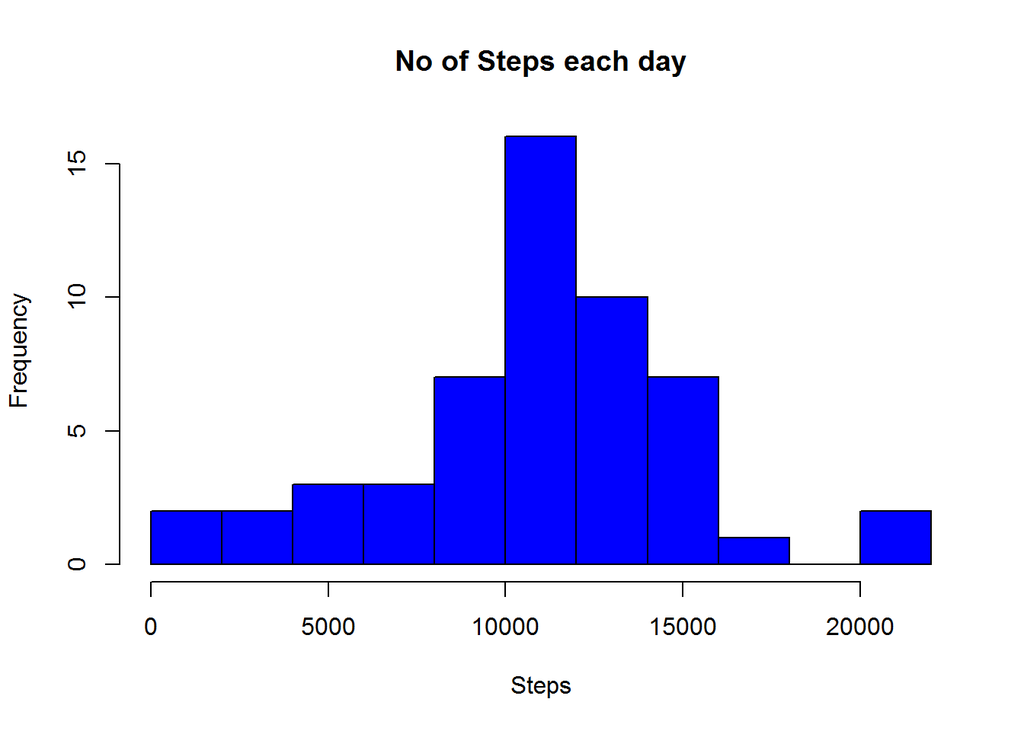

```r
hist(new_dat$steps,breaks=10,col="blue",main="No of Steps each day",xlab = "Steps")
```

```r
dat_mean<-mean(new_dat$steps,na.rm=TRUE)
dat_median<- median(new_dat$steps,na.rm=TRUE)
```

Calculating the average daily pattern

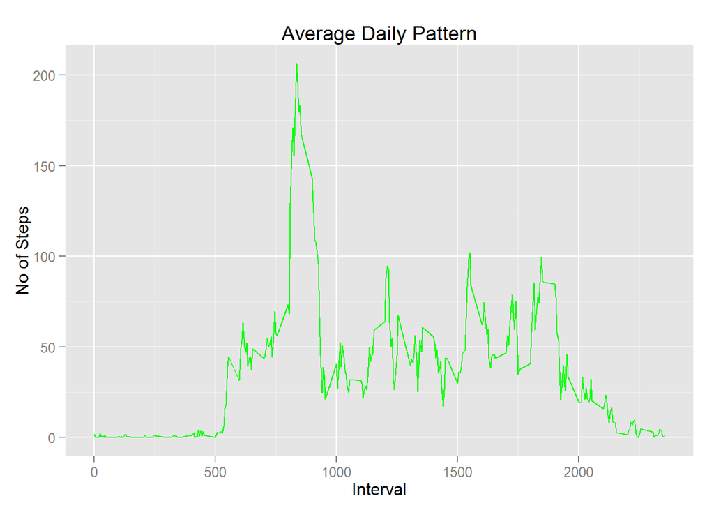

```r
av_dat<-aggregate(act_data$steps, by= list(interval=act_data$interval), FUN=mean,na.rm=TRUE)

av_dat$interval <-
        as.integer(levels(av_dat$interval)[av_dat$interval])
colnames(av_dat)<-c("interval","steps")
ggplot(av_dat,aes(x=interval , y= steps))+geom_line(color="green") + labs( title="Average Daily Pattern", x="Interval", y="No of Steps")
```

```r
max_interval<-av_dat[which.max(av_dat$steps), ]
```

Calculating the total number of missing values

```r
no_NA_nos<- sum(is.na(act_data$steps))
```

Total number of NAs is 2304

```r
na_fill <- function(act_data, pervalue) {
        na_index <- which(is.na(act_data$steps))
        na_replace <- unlist(lapply(na_index, FUN=function(idx){
                interval = act_data[idx,]$interval
                pervalue[pervalue$interval == interval,]$steps
        }))
        fill_steps <- act_data$steps
        fill_steps[na_index] <- na_replace
        fill_steps
}

act_data_fill <- data.frame(
        steps = na_fill(act_data, av_dat),
        date = act_data$date,
        interval = act_data$interval)
str(act_data_fill)
```

```
## 'data.frame':    17568 obs. of  3 variables:
##  $ steps   : num  1.717 0.3396 0.1321 0.1509 0.0755 ...
##  $ date    : Date, format: "2012-10-01" "2012-10-01" ...
##  $ interval: Factor w/ 288 levels "0","5","10","15",..: 1 2 3 4 5 6 7 8 9 10 ...
```

Plotting the graph

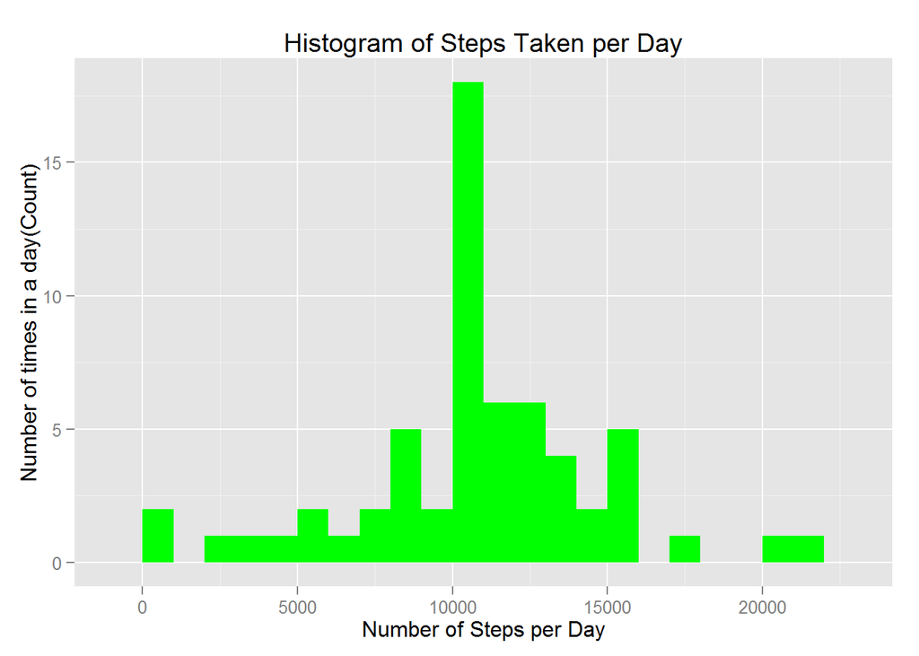

```r
fill_steps_per_day <- aggregate(steps ~ date, act_data_fill, sum)
colnames(fill_steps_per_day) <- c("date","steps")

##plotting the histogram
ggplot(fill_steps_per_day, aes(x = steps)) +
       geom_histogram(fill = "green", binwidth = 1000) +
        labs(title="Histogram of Steps Taken per Day",
             x = "Number of Steps per Day", y = "Number of times in a day(Count)")
```

Calculating and reporting the mean and median

```r
mean_2  <- mean(fill_steps_per_day$steps, na.rm=TRUE)
median_2 <- median(fill_steps_per_day$steps, na.rm=TRUE)
```

Differences in activity patterns between weekdays and weekends

Step1: Adding a column to indicate day of the week

```r
weekdays_steps <- function(data) {
    weekdays_steps <- aggregate(data$steps, by=list(interval = data$interval),
                          FUN=mean, na.rm=T)
    # convert to integers for plotting
    weekdays_steps$interval <-
            as.integer(levels(weekdays_steps$interval)[weekdays_steps$interval])
    colnames(weekdays_steps) <- c("interval", "steps")
    weekdays_steps
}

data_by_weekdays <- function(data) {
    data$weekday <-
            as.factor(weekdays(data$date)) # weekdays
    weekend_data <- subset(data, weekday %in% c("Saturday","Sunday"))
    weekday_data <- subset(data, !weekday %in% c("Saturday","Sunday"))

    weekend_steps <- weekdays_steps(weekend_data)
    weekday_steps <- weekdays_steps(weekday_data)

    weekend_steps$dayofweek <- rep("weekend", nrow(weekend_steps))
    weekday_steps$dayofweek <- rep("weekday", nrow(weekday_steps))

    data_by_weekdays <- rbind(weekend_steps, weekday_steps)
    data_by_weekdays$dayofweek <- as.factor(data_by_weekdays$dayofweek)
    data_by_weekdays
}

data_weekdays <- data_by_weekdays(act_data_fill)
```

Plotting the graph

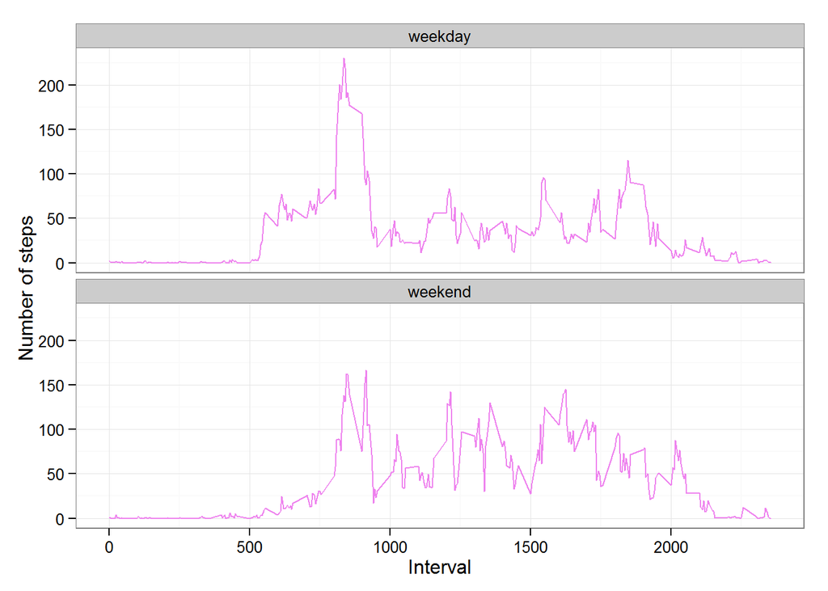

```r
ggplot(data_weekdays, aes(x=interval, y=steps)) +
        geom_line(color="violet") +
        facet_wrap(~ dayofweek, nrow=2, ncol=1) +
        labs(x="Interval", y="Number of steps") +
        theme_bw()
```